# Rapport de groupe des UE Bases de données + Sciences des Données 2

Fenina Sara,

Guilleminot Sarah,

Rakoto Ambinintsoa Prisca,

Sbircea Stephanie.

01 mai 2026

# Introduction

## Problématique

Dans ce projet, nous nous intéressons au système d’échange Wonder Trade du jeu Pokémon, dans lequel les joueurs échangent des Pokémon de manière aléatoire avec d’autres utilisateurs à travers le monde.

La notion de qualité des échanges correspond ici à la valeur perçue des Pokémon échangés, c’est-à-dire au niveau de satisfaction qu’ils procurent aux joueurs. Cette qualité est appréhendée à travers plusieurs dimensions : la puissance du Pokémon (statistiques globales), sa rareté (shiny, légendaire), son niveau d’investissement (niveau, objets, capacités spéciales), ainsi que le ressenti des joueurs lors de l’échange (variable liked).

Ainsi, la problématique étudiée est la suivante :

**Les caractéristiques des Pokémon et des dresseurs influencent-elles la qualité des échanges ?**

Cette question conduit à s’interroger sur le caractère réellement aléatoire des échanges réalisés dans le Wonder Trade du point de vue de la qualité des Pokémon. Il s’agit notamment de déterminer si les joueurs adoptent des comportements différenciés en échangeant davantage des Pokémon moins performants ou moins rares, ou si des Pokémon puissants et recherchés circulent également dans ce système. Cette analyse vise à mettre en évidence les logiques sous-jacentes aux choix d’échange ainsi que les stratégies potentielles des joueurs.

Cette problématique s’inscrit à la fois dans le cadre de l’analyse de données et de l’étude des comportements en environnement numérique. Elle permet d’évaluer si les échanges relèvent d’une logique d’optimisation, caractérisée par la conservation des Pokémon à forte valeur, ou s’ils traduisent des dynamiques plus variées telles que l’aléatoire, la générosité ou des stratégies non systématiques. L’objectif est ainsi de caractériser les déterminants de la qualité des échanges à l’aide d’outils statistiques.

## Composition de l’équipe

# Base de données

## Provenance des données

pokemon: https://www.kaggle.com/datasets/rounakbanik/pokemon)

wonder trades: (https://github.com/solash/pokemon-wondertrade-analytics/blob/master/data/wondertrades-03142015.json)

Nous avons sélectionné la table pokemon car elle contient les données relatives à la description des Pokémon, et la table wonder trade car elle contient les informations concernant les échanges.

Les données des Pokémons sont stockées sous format CSV : le fichier contient 38 colonnes et 802 lignes.

Le fichier wonder trade est sous format Json, il contient 18 colonnes et 201 lignes.

Afin de faciliter l’analyse, nous avons choisi de filtrer certaines colonnes. En effet, toutes les variables n’étaient pas nécessaires pour répondre à notre problématique.

Dans la table pokemon, nous avons conservé uniquement les colonnes les plus pertinentes, notamment celles liées aux caractéristiques principales comme les statistiques (attack, defense, speed, base_total), les types (type1, type2), ainsi que des informations générales comme la génération et le caractère légendaire.

Dans la table wonder trade, nous avons également sélectionné un sous-ensemble de colonnes parmi les 18 colonnes initiales, pour créer les tables trades, trainers et users comme explicité dans la partie import des données.

Ce filtrage permet de réduire le nombre de variables tout en gardant les informations essentielles, ce qui rend l’analyse plus claire et plus pertinente.

La population étudiée correspond à l’ensemble des Pokémon du fichier pokemon.csv ainsi qu’aux échanges du fichier wonder trade.json.

## Descriptif des tables

La table Pokemon sert de dictionnaire de référence. Elle contient toutes les statistiques immuables et globale de chaque espèce de Pokémon (force, types, résistances).

La table Trades est centrale. Elle enregistre l’historique de tous les échanges effectués. Contrairement à la table précédente, les données ici (niveau, objet, shiny) sont spécifiques au spécimen précis qui a été reçu lors de l’échange.

La table Trainers contient les profils des partenaires d’échange. Elle permet de savoir avec qui l’utilisateur a interagi et de quelle région du monde provient le Pokémon reçu.

La table Users est très courte et sert simplement à identifier les comptes locaux sur le logiciel du site web qui a enregistré les données.

## Modèles MCD et MOD

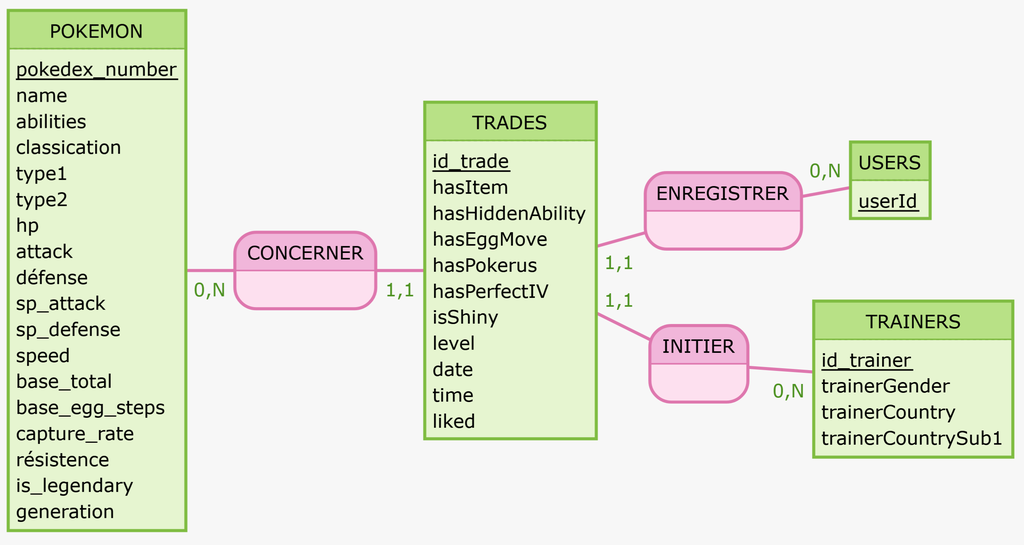

**MCD**.

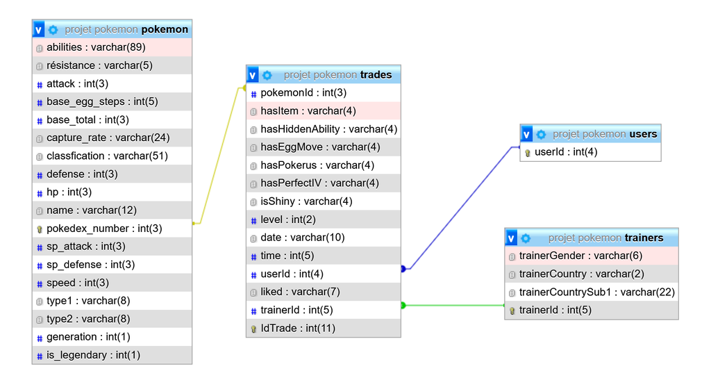

**MOD**.

MOD :

**USERS** (id_user)

**TRADE** (id_trade, hasItem, hasHiddenAbility, hasEggMove,hasPokerus, hasPerfectIV, isShiny, level, date, time, liked, #id_user, #id_trainer, #pokedex_number)

## Import des données

A partir des fichiers **Pokemon** et **WonderTrade**, nous avons créé les tables **Pokemon**, **Trades**, **Trainers** et **Users** comme indiqué si-dessous.

### Création des nouveaux Trainer ID

Directement dans le fichier CSV **WonderTrade** ouvert dans LibreOffice, nous avons procédé de la manière suivante :

Nous avons d’abord activé l’autofiltre sur l’ensemble des données afin de faciliter les opérations de tri, pour ensuite trier par ordre croissant *trainerGender* puis *TrainerCountry* puis *TrainerCountrySub1*.

Ce tri permet de regrouper les lignes présentant des caractéristiques similaires, ce qui est nécessaire pour la suite du traitement.

Nous avons ensuite trié la colonne *trainerId* par ordre croissant. Nous avons constaté que les lignes situées en bas du tableau correspondent aux échanges avec un trainerId vide. Ce sont ces lignes pour lesquelles nous devons créer de nouveaux identifiants.

Nous faisons ici l’hypothèse que des individus ayant le même genre, le même pays et la même sous-localisation correspond à une seule et même personne. Sachant qu’il y a environ 100 lignes sans ID et que les identifiants existants commencent à 783, il n’y aura pas de problème pour créer les nouveaux.

Sous le dernier *trainerId* connu, nous saisissons la valeur 1, puis dans la cellule suivante, nous entrons la formule :

```
  “=SI(J103=J104;SI(K103=K104;SI(L103=L104;Q103;Q103+1);Q103+1);Q103+1)”
```

Nous étirons ensuite cette formule jusqu’à la dernière ligne du tableau.

Cette formule permet de comparer chaque ligne à la précédente : si le genre, le pays et la sous-localisation sont identiques, l’identifiant reste le même ; dans le cas contraire, il est incrémenté de 1.

Nous avons choisi cette méthode en considérant que les trainers partageant les mêmes caractéristiques correspondent à une seule personne. Il aurait également été possible d’attribuer un identifiant distinct à chaque trainer anonyme, mais ce choix n’a pas d’impact sur notre analyse, qui porte sur les caractéristiques des individus (genre, pays, etc.) et non sur leur identification individuelle.

### Création des tables dérivées de WonderTrade

À partir du fichier **WonderTrade** modifié, nous avons construit plusieurs tables :

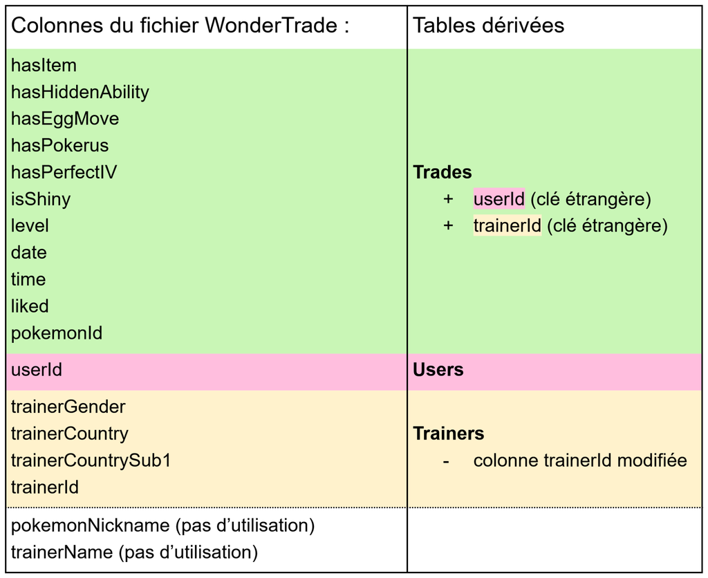

**Schéma explication tables dérivées wondertrade.**

Ce découpage suit rigoureusement les règles de passage du MCD au MOD pour garantir la normalisation de la base de données. Eviter de répéter inutilement les informations. Par exemple, les caractéristiques d’un dresseur (pays, genre) ne sont enregistrées qu’une seule fois dans la table Trainers, même s’il effectue des dizaines d’échanges. Chaque entité distincte identifiée dans notre analyse a été transformée en table indépendante : Users, Trainers et Trades. Pour maintenir les liens relationnels, les identifiants userId et id_trainer ont été intégrés à la table centrale Trades en tant que clés étrangères (#id_user, #id_trainer).

Cette structure relationnelle est indispensable pour réaliser des jointures SQL optimisées et mener les analyses statistiques (ANOVA, Khi$^2$) demandées sans biais de répétition

### Dernières modifications

Table **Pokemon** : Nous avons ouvert le fichier CSV pokemon avec LibreOffice afin de supprimer les colonnes inutiles : *weight_kg, japanese_name, height_m, experience_growth, base_happiness*.

Pour diminuer les colonnes en gardant les données de résistance nécessaire, nous commençons par rechercher et remplacer les “.” par des “,” pour que les réels soient bien tous considérés comme des nombres par LibreOffice.

Ensuite nous créons une nouvelle colonne *résistance* avec le code “=SOMME(B2:S2)” donc la somme de toutes les colonnes commençant par *against*, que nous étirons jusqu’à la dernière ligne. Puis nous faisons un copié collé de cette colonne *résistance* au même endroit en texte non formaté avec un séparateur qui n’est pas ”,”afin de conserver les données après avoir supprimé les autres colonnes, et enfin dernier nous pouvons supprimer toutes les colonnes *against…*.

Tables **Trainers** et **Users** : Nous avons ouvert ces tables dans LibreOffice, puis nous avons trié les données par identifiant croissant, et enfin nous avons ensuite supprimé manuellement les lignes en double.

Table **Trades** : Afin de simplifier l’analyse future, dans LibreOffice nous faisons un copié-collé des noms de colonnes *hasItem, hasHiddenAbility, hasEggMove, hasPokerus, hasPerfectIV et isShiny* à droite des autres colonnes. Nous écrivons ensuite le code “=SI(B2=“FAUX”;0;1)” dans la case sous *hasItem* que nous étirons jusqu’à la dernière case du nouveau *isShiny*. Comme précédemment nous copions et collons en texte non formaté et supprimons les colonnes de trop.

Pour finir wous ajoutons une clé primaire auto-incrémentée dans phpMyAdmin en utilisant la requête SQL suivante :

```
  “ALTER TABLE trades ADD IdTrade INT AUTO_INCREMENT PRIMARY KEY;”
```

# Requêtes réalisées

REQUETE 0: Pokémon échangés

Pour commencer, l’exécution de la requête SQL a permis d’extraire le nombre de pokémon échangé parmi les échanges, et par rapport au nombre total de Pokémon. Cette première requête nous donne une vision d’ensemble et va être à l’origine des autres requêtes qui vous surtout se concentrer sur les pokémons échangés.

```sql
SELECT
    COUNT(DISTINCT t.pokemonId) AS "nb_pokémon_échangés",
    COUNT(t.pokemonId) AS nb_échanges,
   (SELECT COUNT(*) FROM Pokemon) AS "nb_total_pokémon"
FROM Pokemon p
LEFT JOIN Trades t ON p.pokedex_number = t.pokemonId;
```

1 records

| nb_pokémon_échangés | nb_échanges | nb_total_pokémon |
| --- | --- | --- |
| 119 | 200 | 801 |

Nous voyons que 119 pokémons différents sont échangés dans les 200 échanges, donc certains sont échangés plusieurs fois, ce qui peut nous laisser penser que ces échanges ne sont pas une question de hasard. La suite nous aidera à approffondir cette idée.

## Caractéristiques des Pokémon

REQUETE 1: Pokémon de niveau 1(breeding)

Nous cherchons à savoir combien de Pokémon échangés sont de niveau 1, ce qui correspond souvent à des Pokémon issus d’élevage.

```sql
SELECT COUNT(*) AS "nb_pokemon_niveau1"
FROM trades
WHERE level = 1;
```

1 records

| nb_pokemon_niveau1 |
| --- |
| 72 |

Plus d’1/3 des Pokémon sont de niveau 1, donc le niveau le plus faible. Cela montre bien que les joueurs préfèrent échanger des Pokémon moins essentiels en terme de niveau.

REQUETE 2: HP échangés vs non échangés

Nous avons ensuite comparé les points de vie moyens (HP) des Pokémon échangés et non échangés.

L’objectif est de déterminer si les dresseurs ont tendance à échanger des Pokémon plus faibles, plus forts ou équivalents à la moyenne.

```sql
SELECT
(SELECT AVG(hp) FROM pokemon) AS "moyenne.tous.hp",

(SELECT AVG(p.hp) FROM pokemon p, trades t
WHERE p.pokedex_number = t.pokemonId) AS "hp.échangés",

(SELECT AVG(p.hp) FROM pokemon p
WHERE p.pokedex_number IN (SELECT pokemonId FROM trades))
AS "hp.échangés.distincts",

(SELECT AVG(hp) FROM pokemon
WHERE pokedex_number NOT IN (SELECT pokemonId FROM trades))
AS "hp.non.échangeé";
```

1 records

| moyenne.tous.hp | hp.échangés | hp.échangés.distincts | hp.non.échangeé |
| --- | --- | --- | --- |
| 68.9588 | 49.59 | 54.9916 | 71.3959 |

Nous constatons que les Pokémon conservés par les dresseurs affichent une moyenne de 71,40 HP, une valeur supérieure à la moyenne générale du Pokédex (68,96 HP).

À l’inverse, les Pokémon échangés présentent une moyenne de points de vie nettement plus faible, avec une moyenne de 54,99 HP pour les espèces distinctes, qui tombe même à 49,59 HP lorsque l’on analyse l’ensemble des flux, indiquant que les spécimens les plus fragiles sont échangés de manière répétitive.

Dans l’ensemble, ces résultats mettent en évidence une tendance des dresseurs à se séparer des Pokémon les moins robustes au profit de spécimens plus endurants qu’ils préfèrent garder.

À ce stade, la disparité entre les Pokémon échangés et non échangés semble visuellement significative. Cette observation suggère que le niveau de HP est un facteur d’influence majeur dans la décision d’échange, une hypothèse qui sera approfondie par une analyse statistique plus détaillée dans la suite de ce rapport.

REQUETE 3: Types les moins appréciés

Nous avons analysé les types des Pokémons dans les détails pour étudier lesquels sont les moins appréciés.

```sql
SELECT Pokemon.type1, Pokemon.type2, COUNT(*) AS nb_dislikes
FROM Trades
INNER JOIN Pokemon ON Trades.pokemonId = Pokemon.pokedex_number
WHERE Trades.liked = "dislike"
GROUP BY Pokemon.type1, Pokemon.type2
ORDER BY nb_dislikes DESC
LIMIT 1;
```

1 records

| type1 | type2 | nb_dislikes |
| --- | --- | --- |
| normal |  | 11 |

Le type Normal est le moins aimé car il regroupe les Pokémon les plus communs et faciles à capturer dès le début du jeu. Statistiquement, ils possèdent souvent des caractéristiques de combat plus faibles (HP, Attaque, Défense) que les types plus rares ou “exotiques”. Enfin, comme les dresseurs utilisent souvent le Wonder Trade comme un outil d’optimisation pour se débarrasser de leurs spécimens les plus faibles, le système se retrouve saturé de Pokémon de type Normal, provoquant une déception systématique enregistrée dans la colonne liked (dislike) par les destinataires

REQUETE 4: Shiny

Nous avons cherché à identifier les Pokémon shiny présents dans les échanges.

L’objectif est d’évaluer si les Pokémon rares sont fréquemment échangés.

```sql
SELECT COUNT(*) AS nb_shiny
FROM trades
WHERE isShiny = '1';
```

1 records

| nb_shiny |
| --- |
| 1 |

Les résultats montrent qu’ils sont très peu échangés (1 seul), ce qui est logique car ils sont rares et ont une forte valeur pour les joueurs.

Cela confirme un comportement de rétention des ressources rares.

REQUETE 6: Egg Move et HP

Nous avons analysé si la présence d’une capacité spéciale (Egg Move) influence les HP moyens afin de voir si cette caractéristique apporte un avantage mesurable.

```sql
SELECT t.hasEggMove, AVG(p.hp)
FROM pokemon p, trades t
WHERE p.pokedex_number = t.pokemonId
GROUP BY t.hasEggMove;
```

2 records

| hasEggMove | AVG(p.hp) |
| --- | --- |
| 0 | 49.7844 |
| 1 | 48.6061 |

L’analyse croisée entre la présence d’une capacité spéciale (Egg Move) et les points de vie moyens des Pokémon échangés révèle des résultats quasi identiques. Nous observons que les Pokémon possédant un Egg Move affichent 48,61 HP en moyenne, contre 49,78 HP pour ceux n’en possédant pas.

Cet écart semble infime et suggèrerait que la possession d’une capacité rare n’est pas corrélée à une robustesse physique supérieure chez les Pokémon échangés.

L’avantage d’un Egg Move serait purement technique ou tactique, sans influence mesurable sur la statistique de HP. À ce stade, aucune tendance dominante ne semble se dégager visuellement, ce qui indique que ces deux caractéristiques évolueraient de manière indépendante. Un test statistique aiderait à y voir plus clair.

Requête 7 : Relation entre la facilité de capture et le nombre d’échanges

Nous avons étudié la relation entre la facilité de capture et le nombre d’échanges. L’objectif est de tester si les Pokémon faciles à capturer sont plus échangés.

```sql
SELECT Pokemon.capture_rate, COUNT(*) AS nb_echanges
FROM Pokemon
JOIN Trades ON Pokemon.pokedex_number = Trades.pokemonId
GROUP BY Pokemon.capture_rate
ORDER BY nb_echanges DESC;
```

Displaying records 1 - 10

| capture_rate | nb_echanges |
| --- | --- |
| 255 | 62 |
| 45 | 35 |
| 190 | 30 |
| 225 | 13 |
| 200 | 12 |
| 120 | 11 |
| 235 | 9 |
| 180 | 8 |
| 75 | 6 |
| 90 | 3 |

Les résultats montrent que les Pokémon ayant un taux de capture de 255 (le plus élevé possible) dominent largement le classement avec 62 échanges. De manière plus surprenante, les Pokémon ayant un taux de capture de 45 arrivent en deuxième position, alors même qu’ils sont nettement moins faciles à capturer.

Cette distribution confirme que les Pokémon les plus accessibles constituent une part importante des échanges entre dresseurs. Toutefois, la présence marquée de certaines espèces moins faciles à capturer suggère que la fréquence des échanges ne dépend pas uniquement de la facilité d’obtention. D’autres facteurs comme l’intérêt stratégique peuvent également intervenir.

Dans l’ensemble, les données indiquent que les joueurs échangent majoritairement des espèces communes, capturables en grande quantité. À l’inverse, les Pokémon plus rares apparaissent de manière marginale dans les échanges. Une tendance générale se dégage donc : plus un Pokémon est facile à obtenir, plus il circule dans les échanges.

Cette observation devra néanmoins être confirmée par une analyse de corrélation plus rigoureuse dans la suite du rapport, afin de mesurer précisément l’intensité de cette relation.

## Liens entre échanges et trainers

REQUETE 8: Genre du dresseur et capacités du Pokémon

Nous avons étudié le lien entre le genre des dresseurs et les qualités du Pokémon échangé.

L’objectif est de vérifier s’il existe une corrélation entre le genre et ses préférences d’échange.

```sql
SELECT
    tr.trainerGender,
    AVG(
        t.hasItem +
        t.hasHiddenAbility +
        t.hasEggMove +
        t.hasPokerus +
        t.hasPerfectIV +
        t.isShiny
    ) AS score_moyen
FROM trades t
INNER JOIN trainers tr ON t.trainerId = tr.trainerId
INNER JOIN pokemon p ON t.pokemonId = p.pokedex_number
GROUP BY tr.trainerGender;
```

3 records

| trainerGender | score_moyen |
| --- | --- |
|  | 0.0000 |
| female | 0.4118 |
| male | 0.4207 |

Les résultats montrent des scores moyens très proches entre les dresseurs féminins (0,4118) et masculins (0,4207), sur une échelle maximale de 6. Cette différence est négligeable et suggère que le genre n’a pas d’impact notable sur la “qualité” des Pokémon échangés.

En revanche, la catégorie correspondant aux genres non renseignés présente un score nul, ce qui indique que les personnes qui ne voulaient pas s’exposer échangent des pokémons moins qualitatifs.

Globalement, ces résultats indiquent une forte homogénéité des comportements d’échange entre hommes et femmes, le genre ne semblant pas être un facteur discriminant dans la qualité des échanges.

Requête 9 : Anonymat vs qualité

Nous avons comparé les échanges entre dresseurs anonymes et identifiés à partir de plusieurs indicateurs (niveau, shiny, objets, IV…).

L’objectif est de mesurer si l’anonymat influence la qualité des échanges. Elle permet de vérifier si les joueurs anonymes proposent des échanges moins intéressants ou si aucune différence significative n’existe

En revanche la qualité est multidimensionnelle, donc une analyse SQL seule ne suffit pas. Il faudrait pondérer les variables pour créer un score global.

```sql
SELECT 'Anonyme' AS Statut,
AVG(CAST(level AS UNSIGNED))
AS "Niveau.Moy", AVG(isShiny)
* 100 AS "%Shiny", AVG(hasItem)
* 100 AS "%Objet", AVG(hasPerfectIV)
* 100 AS "%IV.Parfait", AVG(hasHiddenAbility)
* 100 AS "%Talent.Caché", AVG(hasEggMove)
* 100 AS "%EggMoves"
FROM trades WHERE trainerId <= 80
UNION ALL
SELECT 'Identifié',
AVG(CAST(level AS UNSIGNED)),
AVG(isShiny)
* 100, AVG(hasItem)
* 100, AVG(hasPerfectIV)
* 100, AVG(hasHiddenAbility)
* 100, AVG(hasEggMove) * 100
FROM trades WHERE trainerId > 80;
```

2 records

| Statut | Niveau.Moy | %Shiny | %Objet | %IV.Parfait | %Talent.Caché | %EggMoves |
| --- | --- | --- | --- | --- | --- | --- |
| Anonyme | 10.6970 | 0.0000 | 3.0303 | 7.0707 | 10.1010 | 21.2121 |
| Identifié | 11.7822 | 0.9901 | 3.9604 | 17.8218 | 4.9505 | 11.8812 |

Il est compliquer d’analyser ces données, les qualités des Pokémon qui changent réelement entre anonyme et identifiés sont le IV parfait qui est bien plus élevé chez les identifiés.

Pourtant la qualité “eggMove” et les talents cachés sont plus élevés chez les individus anonymes. Nous ne pouvons pas tirer de conclusion de cette requête, mais il est tout de même interessant de la garder, pour montrer que tout n’est pas prévisible.

## Conclusion générale

L’ensemble des analyses réalisées sur les échanges Wonder Trade met en évidence que les échanges ne sont pas totalement aléatoires.

Plusieurs facteurs semblent influencer les décisions des joueurs, notamment les caractéristiques des Pokémon et leur niveau de performance. Les résultats montrent que les Pokémon échangés sont fréquemment de niveau faible ou intermédiaire, ce qui suggère une tendance des joueurs à se séparer des Pokémon les moins optimisés.

Par ailleurs, les analyses liées à la rareté indiquent que les Pokémon les plus rares ou difficiles à obtenir sont moins souvent échangés, confirmant un comportement de conservation des ressources précieuses par les joueurs.

Enfin, l’étude des profils de dresseurs montre que certains comportements peuvent varier selon les caractéristiques des utilisateurs, mais ces différences restent globalement modérées.

Dans l’ensemble, ces résultats suggèrent que les échanges Wonder Trade sont influencés par une logique d’optimisation des joueurs, plutôt que purement aléatoire : les Pokémon jugés faibles ou communs sont davantage échangés, tandis que les Pokémon rares ou performants sont majoritairement conservés.

# Analyse statistique

## Définition de la qualité des échanges

La qualité d’un échange dans le système de Wonder Trade ne peut pas être mesurée de manière unique, car une partie importante des données est manquante concernant la satisfaction des joueurs (liked).

Ainsi, la qualité est approchée selon deux dimensions complémentaires :

une mesure subjective, basée sur la satisfaction des joueurs (liked) lorsque celle-ci est renseignée ; une mesure objective, basée sur les caractéristiques des Pokémon échangés, telles que la rareté, la puissance ou la facilité de capture.

Cette double approche permet de limiter le biais lié aux données manquantes et d’obtenir une vision plus complète des échanges.

## Mesure objective de la qualité des Pokémon

Afin de quantifier la qualité intrinsèque des Pokémon échangés, un score a été construit à partir de plusieurs caractéristiques binaires :

présence d’un objet (hasItem) capacité cachée (hasHiddenAbility) egg move (hasEggMove) présence de Pokérus (hasPokerus) IV parfaits (hasPerfectIV) Pokémon shiny (isShiny)

Chaque caractéristique vaut 0 ou 1, et leur somme constitue un score de qualité compris entre 0 et 6.

Ce score permet d’évaluer le niveau global d’optimisation ou de rareté des Pokémon échangés.

## Test de Corrélation

### Capture rate x échange**

Dans cette analyse, nous cherchons à étudier la relation entre la facilité de capture d’un Pokémon et sa fréquence d’échange dans le système Wonder Trade.

Le taux de capture (capture_rate) constitue un indicateur de rareté :

un taux élevé correspond à un Pokémon facile à capturer (donc commun), un taux faible correspond à un Pokémon rare ou difficile à obtenir.

L’objectif est donc de déterminer si la fréquence des échanges est influencée par cette caractéristique, autrement dit si les joueurs ont tendance à échanger davantage des Pokémon communs plutôt que rares.

Hypothèses : Nous utilisons ici un test de corrélation linéaire (Pearson) afin de mesurer l’intensité et le sens de la relation entre deux variables quantitatives.

**Hypothèse nulle(H0)** : il n’existe aucune corrélation entre le taux de capture et le nombre d’échanges c’est-à-dire que la fréquence des échanges est indépendante de la rareté du Pokémon **Hypothèse alternative(H1)** : il existe une corrélation entre le taux de capture et le nombre d’échanges c’est-à-dire que la rareté influence les décisions d’échange des joueurs

```
##       cor
## 0.2336852
```

```
## [1] 0.01053322
```

**Interprétation du test**

La p-value est de 0.01053. Comme elle est inférieure au seuil classique de 0,05, on rejette l’hypothèse nulle. Cela signifie qu’il existe une relation statistiquement significative entre le taux de capture et le nombre d’échanges dans tes données. Ce n’est pas dû au pur hasard.

Le coefficient de corrélation (cor) est de 0.233.

C’est une corrélation positive : quand le capture_rate augmente (donc quand le Pokémon est plus facile à capturer), le nombre d’échanges a tendance à augmenter aussi.

Cependant, 0.23 est considéré comme une corrélation faible. La relation existe, mais elle n’est pas très forte. Beaucoup d’autres facteurs influencent probablement le nombre d’échanges.

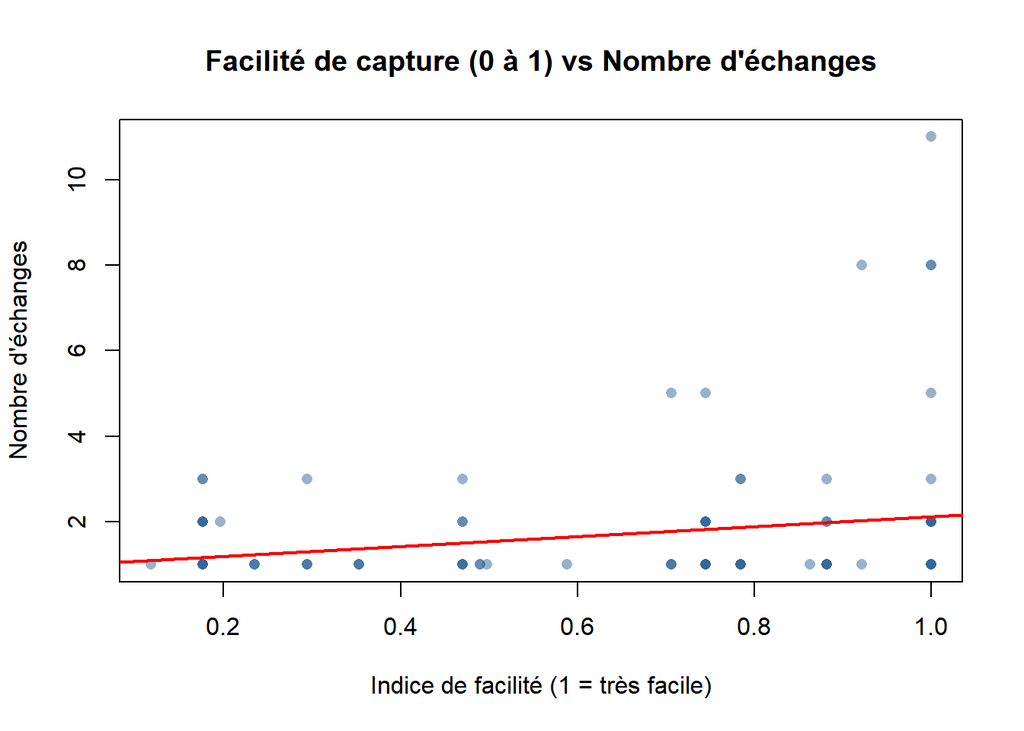

**Interprétation graphique**

Le graphique présente le nombre d’échanges en fonction de l’indice de facilité de capture (normalisé de 0 à 1).On observe une dispersion importante des points, confirmant la faiblesse du coefficient de corrélation (cor = 0,23). Néanmoins, la droite de régression (en rouge) montre une pente ascendante vers la droite.Plus l’indice tend vers 1 (Pokémon techniquement très faciles à capturer comme les espèces communes), plus la fréquence des échanges augmente. À l’inverse, les Pokémon dont l’indice est proche de 0 (espèces rares ou légendaires) sont moins présents en volume. Cette observation suggère que le flux du Wonder Trade est alimenté par l’abondance des captures faciles plutôt que par la rareté.

**Conclusion du test**

Le test de corrélation met en évidence une relation significative entre la facilité de capture et le nombre d’échanges. Les Pokémon faciles à capturer sont légèrement plus échangés, ce qui traduit un effet d’abondance dans le système. Cependant, l’intensité de cette relation reste faible, ce qui indique que la rareté n’est qu’un facteur parmi d’autres dans les décisions d’échange. Ainsi, même si la disponibilité influence les échanges, elle ne suffit pas à expliquer entièrement le comportement des joueurs.

## Test ANOVA

### ANONYMAT × NIVEAU(Qualité)**

Dans un premier temps, nous avons cherché à analyser le comportement des joueurs en fonction de leur statut (anonyme ou identifié) à l’aide d’une requête SQL.

Cette requête permet de regrouper les Pokémon échangés par classes de niveau (tranches de 5 niveaux) et de comparer leur distribution selon le statut du dresseur.

L’objectif est d’obtenir une première vision descriptive des échanges afin d’identifier d’éventuelles différences de comportement entre les deux groupes.

```sql
SELECT
    CASE
        WHEN trainerId <= 80 THEN 'Anonyme'
        ELSE 'Identifié'
    END AS Statut,
    CONCAT(
        FLOOR((CAST(level AS UNSIGNED)-1)/5)*5 + 1,
        '-',
        FLOOR((CAST(level AS UNSIGNED)-1)/5)*5 + 5
    ) AS Classe_Niveau,
    COUNT(*) AS Effectif
FROM trades
GROUP BY Statut, Classe_Niveau
ORDER BY Statut, Classe_Niveau;
```

Displaying records 1 - 10

| Statut | Classe_Niveau | Effectif |
| --- | --- | --- |
| Anonyme | 1-5 | 61 |
| Anonyme | 11-15 | 6 |
| Anonyme | 16-20 | 5 |
| Anonyme | 21-25 | 6 |
| Anonyme | 26-30 | 5 |
| Anonyme | 31-35 | 4 |
| Anonyme | 36-40 | 5 |
| Anonyme | 41-45 | 2 |
| Anonyme | 46-50 | 1 |
| Anonyme | 6-10 | 4 |

Cette analyse descriptive permet d’observer la répartition des niveaux échangés et de vérifier visuellement si certains groupes semblent privilégier des niveaux spécifiques.

Cependant, cette approche reste descriptive et ne permet pas de conclure statistiquement à l’existence d’une différence entre les groupes.

Nous complétons donc cette analyse par un test statistique (ANOVA) afin de comparer rigoureusement les niveaux moyens entre dresseurs anonymes et identifiés. Dans cette analyse, nous cherchons à étudier l’effet de l’anonymat du dresseur sur le niveau des Pokémon échangés dans le système Wonder Trade.

L’anonymat n’étant pas directement présent dans la base, nous le reconstruisons à partir du trainerId :

trainerId ≤ 80 : dresseur anonyme trainerId > 80 : dresseur identifié

Le niveau (level) est utilisé ici comme indicateur de qualité : un niveau élevé peut refléter un Pokémon plus entraîné ou plus intéressant à échanger.

L’objectif est donc de déterminer si les joueurs anonymes échangent des Pokémon de niveau différent par rapport aux joueurs identifiés.

Hypothèses

Nous utilisons ici une analyse de variance (ANOVA), adaptée à la comparaison de moyennes entre plusieurs groupes.

**Hypothèse nulle(H0)** : le niveau moyen est identique entre les groupe, c’est-à-dire que l’anonymat n’a aucun effet sur la qualité des échanges

**Hypothèse alternative(H1)**: au moins une moyenne diffère, c’est-dire-que l’anonymat influence la qualité des Pokémon échangés

```
##              Df Sum Sq Mean Sq F value Pr(>F)
## anonymat      1     59   58.88   0.323  0.571
## Residuals   198  36130  182.48
```

**Interprétation du test**

La p-value obtenue est de 0.571, ce qui est largement supérieur au seuil de 0.05.

On ne rejette donc pas l’hypothèse nulle.

Cela signifie qu’il n’existe aucune différence statistiquement significative entre le niveau moyen des Pokémon échangés par des dresseurs anonymes et ceux échangés par des dresseurs identifié

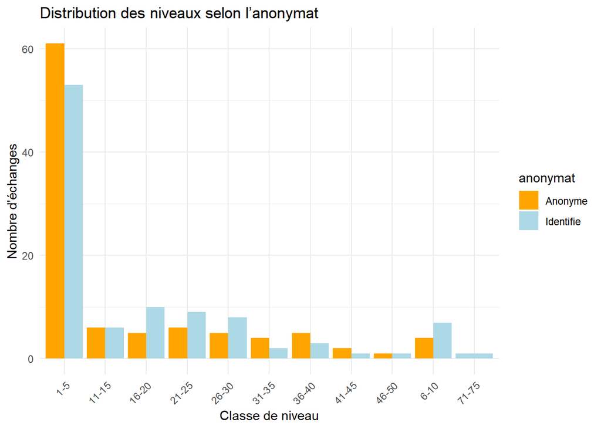

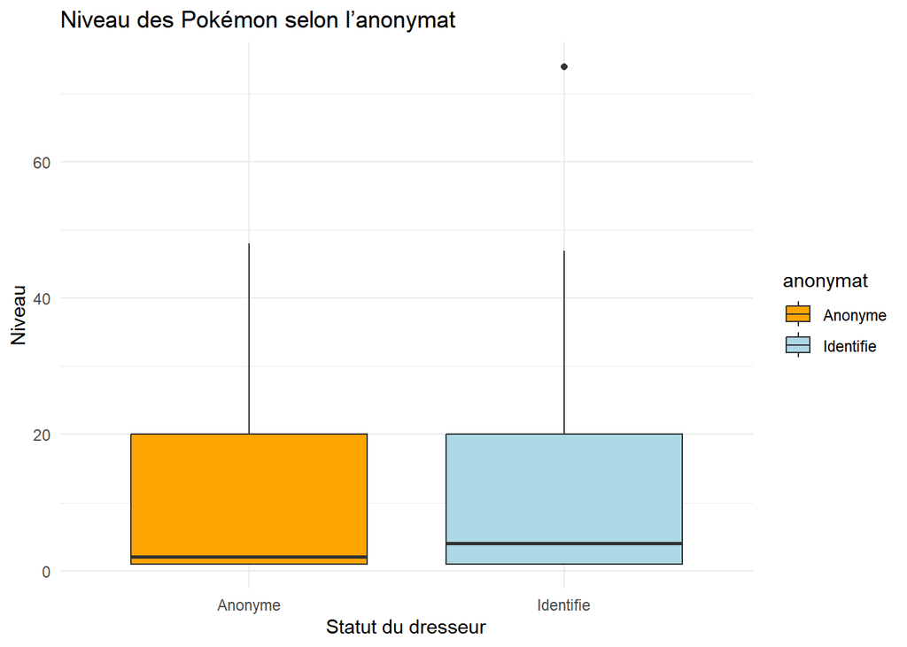

**Interprétation graphique**

Le premier graphique (histogramme par classes de niveau) permet d’observer la répartition des échanges selon des tranches de niveaux pour les dresseurs anonymes et identifiés.

On constate que :

La majorité des échanges se concentre dans les faibles niveaux (1–5) pour les deux groupes Les distributions sont très similaires entre anonymes et identifiés Il n’y a pas de classe de niveau dominante propre à un groupe Quelques variations existent (ex : légèrement plus d’identifiés dans certaines classes), mais elles restent faibles et irrégulières

Cela suggère que les deux types de joueurs échangent globalement les mêmes niveaux

Le second graphique (boxplot) permet d’analyser la distribution globale des niveaux :

Les deux graphiques convergent vers la même conclusion : Les dresseurs anonymes et identifiés échangent des Pokémon de niveaux très similaires Il n’y a ni différence structurelle, ni tendance claire distinguant les deux groupes

**Conclusion du test**

Les visualisations confirment les résultats du test ANOVA : les distributions de niveaux sont très similaires entre dresseurs anonymes et identifiés. L’anonymat ne semble donc pas influencer le niveau des Pokémon échangés dans le système Wonder Trade.

## Analyse statistique

L’objectif de cette analyse est de déterminer si les caractéristiques des Pokémon et des dresseurs influencent la qualité des échanges dans le système de Wonder Trade.

La qualité d’un échange est mesurée à l’aide de la variable liked, qui traduit le ressenti du joueur (échange apprécié ou non).

Nous analysons deux dimensions principales :

Les caractéristiques intrinsèques du Pokémon : rareté (shiny), puissance, facilité de capture Les caractéristiques liées au dresseur : comportement et investissement (niveau)

Afin de répondre à cette problématique, nous mobilisons plusieurs outils statistiques : le test du Khi², l’analyse de variance (ANOVA) et un test de corrélation, ainsi qu’une régression logistique permettant d’avoir une vision globale.

Dans un souci de cohérence, nous organisons l’analyse en distinguant d’abord les facteurs liés aux Pokémon, puis ceux liés aux dresseurs, avant de les comparer et de répondre à la problématique.

##I. Influence des caractéristiques du Pokémon sur la qualité des échanges

## Influence de la rareté sur la satisfaction (Test du Khi$^2$)

**ojectif**

Lorsque nous observons la répartition des Pokémon échangés selon leur rareté (par exemple shiny ou non shiny), nous remarquons que certaines catégories sont très peu représentées par rapport à d’autres. Cela peut laisser penser que les échanges ne sont pas totalement aléatoires, mais influencés par le comportement des joueurs.

Lorsque nous observons la répartition des Pokémon échangés, certaines catégories, notamment les Pokémon rares, apparaissent moins fréquentes. Cela suggère que les échanges pourraient ne pas être totalement aléatoires, mais influencés par des choix stratégiques des joueurs. Nous cherchons donc à déterminer si le fait qu’un Pokémon soit shiny influence la satisfaction des joueurs (liked).

Hypothèses statistiques

#H0 (Hypothèse nulle) : La rareté du Pokémon n’influence pas la satisfaction (indépendance).

#H1 (Hypothèse alternative) : La rareté influence la satisfaction (dépendance).

### Données et calculs

```
##
##     dislike like no_opinion
##   0      59   30        110
##   1       0    1          0
```

Effectifs théoriques

```
## Warning in chisq.test(shiny_liked): L’approximation du Chi-2 est peut-être
## incorrecte
```

```
##
##     dislike   like no_opinion
##   0  58.705 30.845     109.45
##   1   0.295  0.155       0.55
```

le message affiché “## Warning in chisq.test(shiny_liked): L’approximation du Chi-2 est peut-être incorrecte” vient du fait qu’il n’y est qu’un seul individu skiny, ce qui n’est pas très représentatif.

Test du Khi$^2$

```
## Warning in chisq.test(shiny_liked): L’approximation du Chi-2 est peut-être
## incorrecte
```

```
## X-squared
##  5.479008
```

```
## [1] 0.06460238
```

Mesure de l’intensité de la relation (V de Cramer)

Pour compléter le test, nous calculons le coefficient de Cramer qui mesure la force de l’association :

```
## X-squared
## 0.1655145
```

```
## X-squared
## 0.1655145
```

## Distribution des échanges selon le taux de capture

l’avertissement “## Warning: le package ‘ggplot2’ a été compilé avec la version R 4.5.3” signifie simplement que ggplot2 a été créé avec une version de R plus récente que la notre, mais il reste fonctionnel et sans danger pour nos analyses.

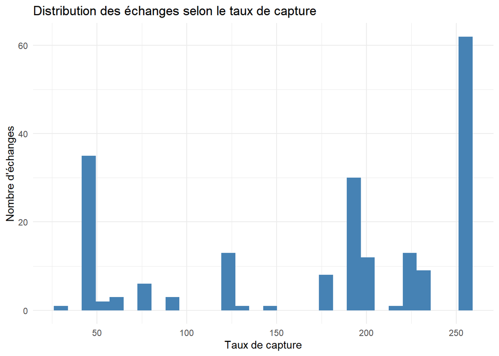

**Interprétation**

Ce graphique met en évidence la répartition des échanges selon le taux de capture.

On observe que les Pokémon ayant un taux de capture élevé sont plus présents dans les échanges.

**Conclusion**

Les échanges sont en partie influencés par la disponibilité des Pokémon. Les Pokémon faciles à capturer sont plus fréquemment échangés, ce qui suggère un effet d’abondance dans le système de Wonder Trade.

##Corrélation entre taux de capture et nombre d’échanges

```
##       cor
## 0.2336852
```

```
## [1] 0.01053322
```

Visualisation de la corrélation

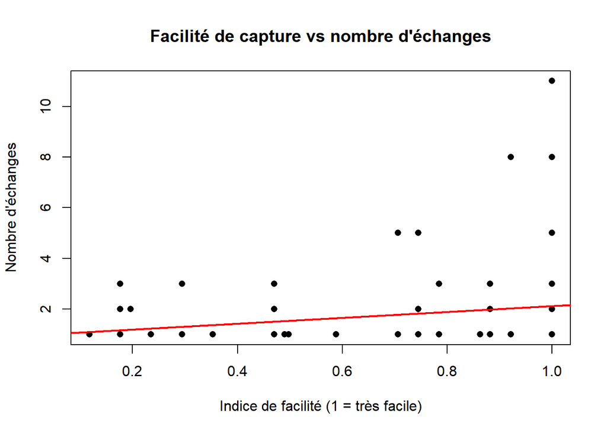

Interprétation

La p-value est de 0.0105, ce qui indique une relation significative. Le coefficient (0.23) montre une corrélation positive mais faible.

Conclusion

Les Pokémon faciles à capturer sont légèrement plus échangés.

## Influence de la puissance des Pokémon (ANOVA)

**Objectif**

Nous cherchons à déterminer si la puissance des Pokémon (base_total) varie selon les groupes de dresseurs.

**Préparation des données**

Visualisation

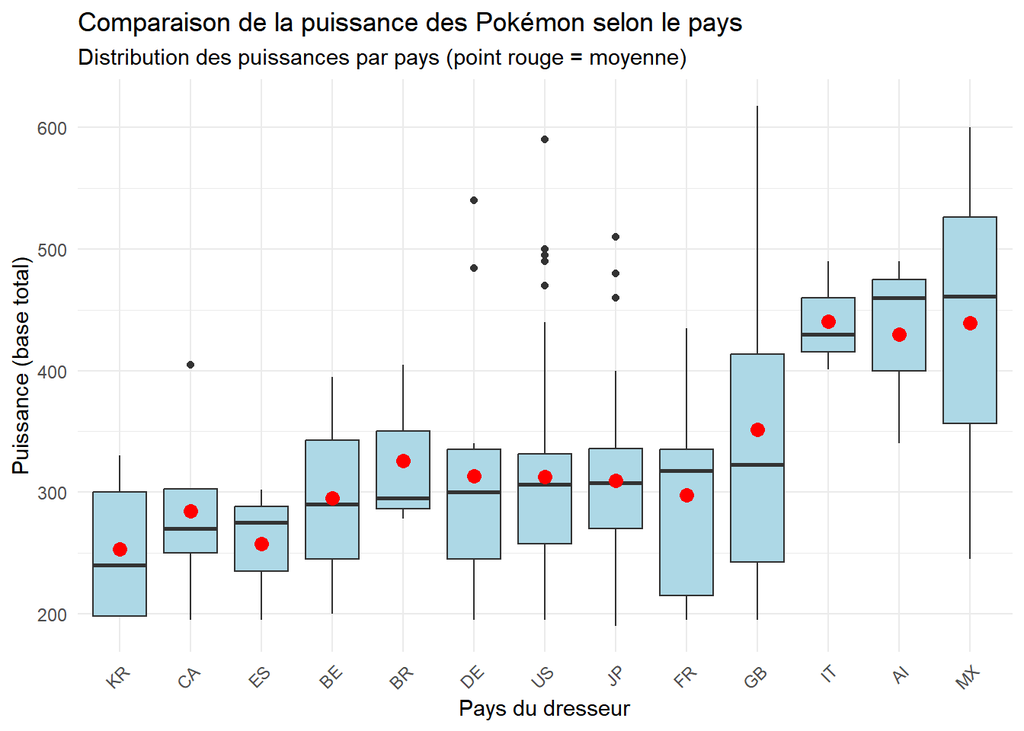

**Interprétation du graphique**

Chaque boîte représente un pays.

la ligne centrale correspond à la médiane le point rouge correspond à la moyenne la dispersion reflète la variabilité

On observe des différences de puissance entre les pays.

## Test ANOVA

```
##                 Df  Sum Sq Mean Sq F value Pr(>F)
## trainerCountry  20  302236   15112   1.862 0.0176 *
## Residuals      179 1452509    8115
## ---
## Signif. codes:  0 '***' 0.001 '**' 0.01 '*' 0.05 '.' 0.1 ' ' 1
```

**Interprétation**

La p-value obtenue est 0.0176, donc inférieure à 0.05.

On rejette l’hypothèse nulle.

**Conclusion**

La puissance des Pokémon échangés varie significativement selon les groupes de dresseurs.

Cela indique que les échanges ne sont pas homogènes et reflètent des comportements différenciés selon les joueurs.

**Méthodologie**

Nous utilisons une régression logistique, car :

la variable liked est qualitative (succès / échec) on cherche à expliquer une probabilité **Préparation des données** **Transformation de liked en variable binaire**

**Fusion des données**

Modèle de régression

```
## Warning: glm.fit : l'algorithme n'a pas convergé
```

```
##
## Call:
## glm(formula = liked_bin ~ isShiny + base_total + capture_rate +
##     level, family = "binomial", data = df_model)
##
## Coefficients:
##                Estimate Std. Error z value Pr(>|z|)
## (Intercept)  -2.657e+01  1.722e+05       0        1
## isShiny       1.189e-14  3.810e+05       0        1
## base_total    5.015e-17  4.038e+02       0        1
## capture_rate -4.041e-17  4.091e+02       0        1
## level         6.663e-17  2.379e+03       0        1
##
## (Dispersion parameter for binomial family taken to be 1)
##
##     Null deviance: 0.0000e+00  on 199  degrees of freedom
## Residual deviance: 1.1603e-09  on 195  degrees of freedom
## AIC: 10
##
## Number of Fisher Scoring iterations: 25
```

**Conclusion**

http://biostatisticien.eu/springeR/livreR.pdf

# Limites et percpectives

## Difficultés rencontrées

La réalisation de ce projet a mis en évidence plusieurs limites, à la fois techniques, méthodologiques et liées aux données.

Tout d’abord, un problème important concerne le déséquilibre des données. En particulier, les Pokémon shiny sont extrêmement rares dans notre base (un seul individu), ce qui limite fortement la portée des analyses statistiques. Cette rareté entraîne des avertissements lors du test du Khi2 et réduit la fiabilité des résultats concernant l’impact de la rareté sur la satisfaction.

Le site qu’on voulait à l’origine pour récupérer nos données été fermé donc on a du chercher des données sur github où il y avait des données manquante(NA). La présence de ces données manquantes constitue une autre limite. Certaines variables, comme le genre des dresseurs ou l’avis sur l’échange (liked), comportent des valeurs absentes. Même si nous avons choisi d’introduire une catégorie “sans avis” afin de conserver ces observations, cela peut introduire un biais d’interprétation, car l’absence de réponse ne reflète pas nécessairement une opinion neutre.

Par ailleurs, certaines hypothèses simplificatrices ont été nécessaires lors du traitement des données. Par exemple, nous avons supposé que des dresseurs ayant les mêmes caractéristiques (genre, pays, région) correspondaient à une seule et même personne. Cette approximation peut entraîner une perte de précision dans l’analyse des comportements individuels.

De plus, la variable de satisfaction (liked) reste une mesure subjective et imparfaite de la qualité des échanges. Elle ne prend pas en compte toutes les dimensions possibles, comme la stratégie du joueur, la valeur émotionnelle ou encore l’utilité future du Pokémon reçu.

Enfin, les données utilisées datent de **2015**, ce qui constitue une limite temporelle importante. Les comportements des joueurs peuvent avoir évolué avec les nouvelles versions du jeu et les changements dans les mécaniques d’échange.

## Perspectives

Plusieurs pistes pourraient être envisagées afin d’améliorer et d’approfondir cette étude. Tout d’abord, il serait pertinent de disposer d’un jeu de données plus récent et plus volumineux, incluant davantage de Pokémon rares (notamment shiny), afin d’obtenir des résultats statistiques plus robustes et représentatifs.Ensuite, une amélioration importante consisterait à construire un indice de qualité des échanges plus complet, en combinant plusieurs variables (niveau, statistiques, rareté, capacités spéciales). Cela permettrait de dépasser la simple variable liked et d’obtenir une mesure plus objective.Il serait également intéressant d’intégrer des variables supplémentaires, telles que :la nature du Pokémon, ou les objets tenus,afin d’affiner l’analyse du comportement des joueurs, notamment dans une perspective compétitive.Par ailleurs, des méthodes plus avancées pourraient être mobilisées, comme des modèles de machine learning (par exemple Random Forest ou régression logistique améliorée) pour prédire la probabilité qu’un échange soit apprécié.Enfin, une extension possible serait d’analyser la dimension temporelle des échanges, afin d’identifier d’éventuelles tendances selon les périodes ou les régions du monde. En conclusion, malgré certaines limites liées aux données et aux hypothèses retenues, ce projet constitue une première approche pertinente de l’analyse des comportements dans le système Wonder Trade. Les perspectives évoquées ouvrent la voie à des analyses plus fines et plus complètes.

# Discussion

L’analyse de nos résultats permet de mettre en lumière plusieurs phénomènes structurants du système Wonder Trade, en confrontant les données statistiques aux comportements des joueurs.

## Le paradoxe de l’abondance et du recyclage

La corrélation de Pearson entre le taux de capture et le volume d’échanges (0.23) confirme que le système est saturé par des Pokémon dits “communs”. Les joueurs utilisent majoritairement le Wonder Trade pour recycler des Pokémon capturés facilement lors de leur aventure. Cependant, cette faible corrélation indique aussi que le système n’est pas uniquement une déchetterie : une part non négligeable d’échanges concerne des Pokémon rares, ce qui entretient l’attractivité de la plateforme.

## Limites de l’étude

Comme souligné dans les rapports de référence, toute analyse de données comporte des limites :

Temporalité : Les données datent de 2015, ce qui correspond à la sixième génération de Pokémon. Les comportements pourraient différer sur les versions plus récentes (Switch).

# Bibliographie

Jean-Michel, R. (2023). Manuel de Statistiques avec R.

Bringay, S., & Ben-Sassi, I. Supports de cours : Bases de Données et Sciences des Données 2, Université Paul Valéry Montpellier 3.

DellaData. L’ANOVA à un facteur : théorie et pratique. Consulté sur https://delladata.fr.

The Pokémon Company. Données issues du système Global Trade Station (GTS).

StackOverFlow: Divers questions.